# CMTH 642 Data Analytics: Advanced Methods

# Assignment 1 (10%)

### DHC - 500163559

#### 1. Read the csv files in the folder. (3 points)

```r
dfMacro <- read.csv("USDA_Macronutrients.csv")
dfMicro <- read.csv("USDA_Micronutrients.csv")
```

#### 2. Merge the data frames using the variable “ID”. Name the Merged Data Frame “USDA”. (6 points)

```r
USDA <- merge(dfMacro, dfMicro, by="ID")
```

#### 3. Check the datatypes of the attributes. Delete the commas in the Sodium and Potasium records. Assign Sodium and Potasium as numeric data types. (6 points)

```r
# check datatype of attributes
sapply(USDA, class)
```

```
##           ID  Description     Calories      Protein     TotalFat Carbohydrate
##    "integer"  "character"    "integer"    "numeric"    "numeric"    "numeric"
##       Sodium  Cholesterol        Sugar      Calcium         Iron    Potassium
##  "character"    "integer"    "numeric"    "integer"    "numeric"  "character"
##     VitaminC     VitaminE     VitaminD
##    "numeric"    "numeric"    "numeric"
```

```r
# substitute commas with periods
USDA$Sodium <- sub(',','',USDA$Sodium)
USDA$Potassium <- sub(',','',USDA$Potassium)

# change sodium and potassium to numeric
USDA$Sodium <- as.numeric(USDA$Sodium)
USDA$Potassium <- as.numeric(USDA$Potassium)

# double check to make sure the datatype change is good.
is.numeric(sapply(USDA$Sodium, as.numeric))
```

```
## [1] TRUE
```

```r
is.numeric(sapply(USDA$Potassium, as.numeric))
```

```
## [1] TRUE
```

#### 4. Remove records (rows) with missing values in more than 4 attributes (columns). How many records remain in the data frame? (6 points)

```r
USDA.nacount <- apply(USDA,1, function(x) sum(is.na(x)))
USDATrim <- USDA[USDA.nacount <= 4,]
nrow(USDATrim)
```

```
## [1] 6887
```

```r
# 6887 records
```

#### 5. For records with missing values for Sugar, Vitamin E and Vitamin D, replace missing values with mean value for the respective variable. (6 points)

```r
sugarMean <- mean(USDATrim$Sugar, na.rm=T)
vitEMean <- mean(USDATrim$VitaminE, na.rm=T)
vitDMean <- mean(USDATrim$VitaminD, na.rm=T)
USDATrim[is.na(USDATrim$Sugar),'Sugar'] <- sugarMean
USDATrim[is.na(USDATrim$VitaminE),'VitaminE'] <- vitEMean
USDATrim[is.na(USDATrim$VitaminD),'VitaminD'] <- vitDMean
```

#### 6. With a single line of code, remove all remaining records with missing values. Name the new Data Frame “USDAclean”. How many records remain in the data frame? (6 points)

```r
USDAClean <- na.omit(USDATrim)
nrow(USDAClean)
```

```
## [1] 6310
```

```r
# 6310 records
```

#### 7. Which food has the highest sodium level? (6 points)

```r
head(USDAClean[order(USDAClean$Sodium, decreasing = T),],1)
```

```
##       ID Description Calories Protein TotalFat Carbohydrate Sodium Cholesterol
## 265 2047  SALT,TABLE        0       0        0            0  38758           0
##     Sugar Calcium Iron Potassium VitaminC VitaminE VitaminD
## 265     0      24 0.33         8        0        0        0
```

```r
# ID 2047 has the highest Sodium of 38758
```

#### 8. Create a histogram of Vitamin C distribution in foods. (6 points)

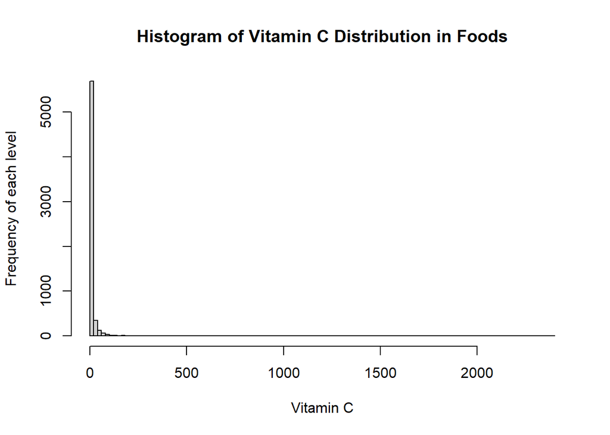

```r
hist(USDAClean$VitaminC, breaks = 100, xlab = "Vitamin C", ylab= "Frequency of each level", main="Histogram of Vitamin C Distribution in Foods" )
```

#### 9. Create a boxplot to illustrate the distribution of values for TotalFat, Protein and Carbohydrate. (6 points)

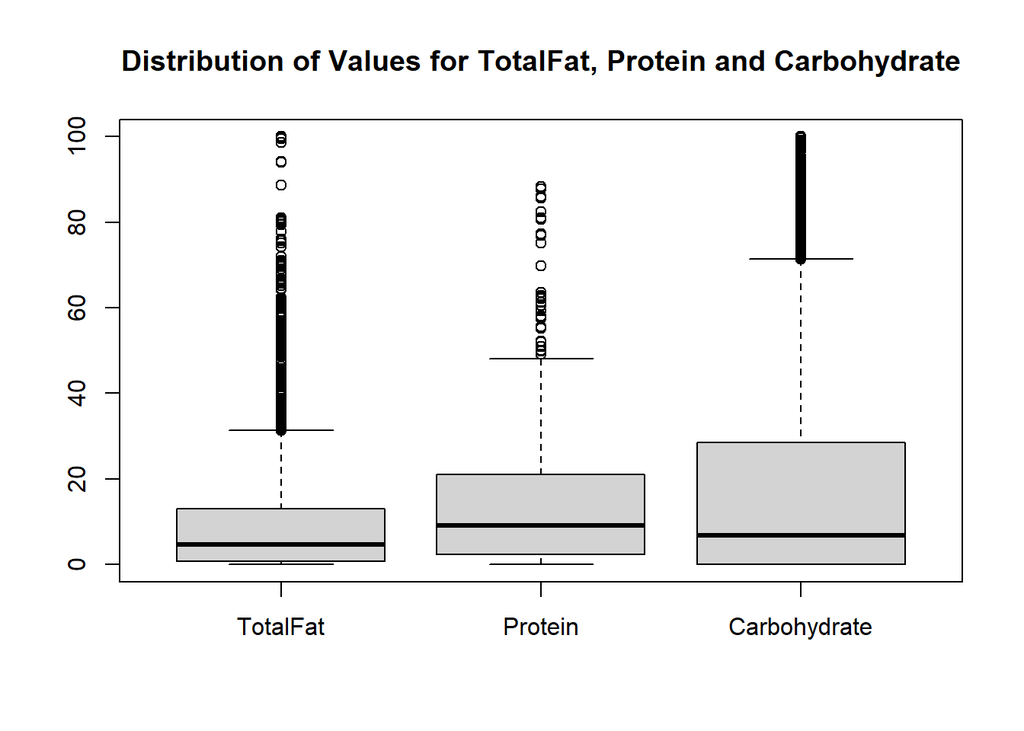

```r
TPCdata <- list(USDAClean$TotalFat, USDAClean$Protein, USDAClean$Carbohydrate)
names(TPCdata) <- c("TotalFat", "Protein", "Carbohydrate")
boxplot(TPCdata, main="Distribution of Values for TotalFat, Protein and Carbohydrate")
```

#### 10. Create a scatterplot to illustrate the relationship between a food’s TotalFat content and its Calorie content. (6 points)

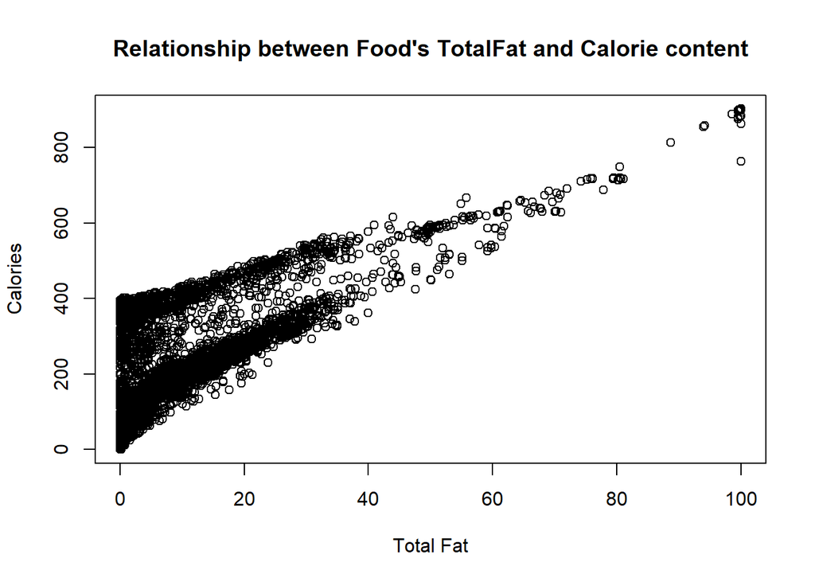

```r
plot(USDAClean$Calories~USDAClean$TotalFat, main="Relationship between Food's TotalFat and Calorie content", ylab="Calories", xlab="Total Fat")
```

#### 11. Add a variable to the data frame that takes value 1 if the food has higher sodium than average, 0 otherwise. Call this variable HighSodium. Do the same for High Calories, High Protein, High Sugar, and High Fat. How many foods have both high sodium and high fat? (8 points)

```r
USDAClean$HighSodium <- ifelse(USDAClean$Sodium > mean(USDAClean$Sodium), 1, 0 )
USDAClean$HighCalories <- ifelse(USDAClean$Calories > mean(USDAClean$Calories), 1, 0 )
USDAClean$HighProtein <- ifelse(USDAClean$Protein > mean(USDAClean$Protein), 1, 0 )
USDAClean$HighSugar <- ifelse(USDAClean$Sugar > mean(USDAClean$Sugar), 1, 0 )
USDAClean$HighTotalFat <- ifelse(USDAClean$TotalFat > mean(USDAClean$TotalFat), 1, 0 )
nrow(USDAClean[(USDAClean$HighSodium == 1 & USDAClean$HighTotalFat == 1),])
```

```
## [1] 644
```

```r
# 644 foods high sodium and high fat.
```

#### 12. Calculate the average amount of iron, for high and low protein foods. (8 points)

```r
mean(USDAClean$Iron[USDAClean$HighProtein == 1],)
```

```
## [1] 3.069541
```

```r
mean(USDAClean$Iron[USDAClean$HighProtein == 0],)
```

```
## [1] 2.696634
```

```r
# 3.069541 Iron for High Protein
# 2.696634 Iron for Low Protein
```

```r
# require(jpeg)
# img<-readJPEG("HealthCheck.jpg")
# plot(1:4, ty = 'n', ann = F, xaxt = 'n', yaxt = 'n')
# rasterImage(img,1,1,4,4)
```

```r
healthCheck <- function(arg1) {
  # FALSE = healthy
  # TRUE = unhealthy
  return (prod(arg1));
}
```

#### 14. Add a new variable called HealthCheck to the data frame using the output of the function. (8 points)

```r
# True = Failed HealthCheck
# False = Pass HealthCheck
USDAClean$HealthCheck <- apply(USDAClean[,c("HighSodium","HighSugar","HighTotalFat")],1, function(x) as.logical(healthCheck(x)))
```

#### 15. How many foods in the USDAclean data frame fail the HealthCheck? (8 points)

```r
nrow(USDAClean[USDAClean$HealthCheck==T,])
```

```
## [1] 237
```

```r
# 237
```

#### 16. Save your final data frame as “USDAclean_ [your last name].” (3 points)

```r
write.csv(USDAClean,"USDAclean_Lee.csv")
```

This is the end of Assignment 1

Ceni Babaoglu, PhD